# final_presentation_internship slides

[figure not shown]

## About LIQOMICS

- Academic spin-off from Cologne
- Advancing liquid biopsy technology for tumor diagnostics
- LymphoVista:
  - Service to Detect and Monitor Lymphomas and Hematological Cancers
  - Analysis of blood samples to detect cell-free DNA (cfDNA) and cirulating tumor DNA (ctDNA)
  - Monitors minimal residual disease (MRD)

## Highly sensitive MRD test to monitor cancer progression

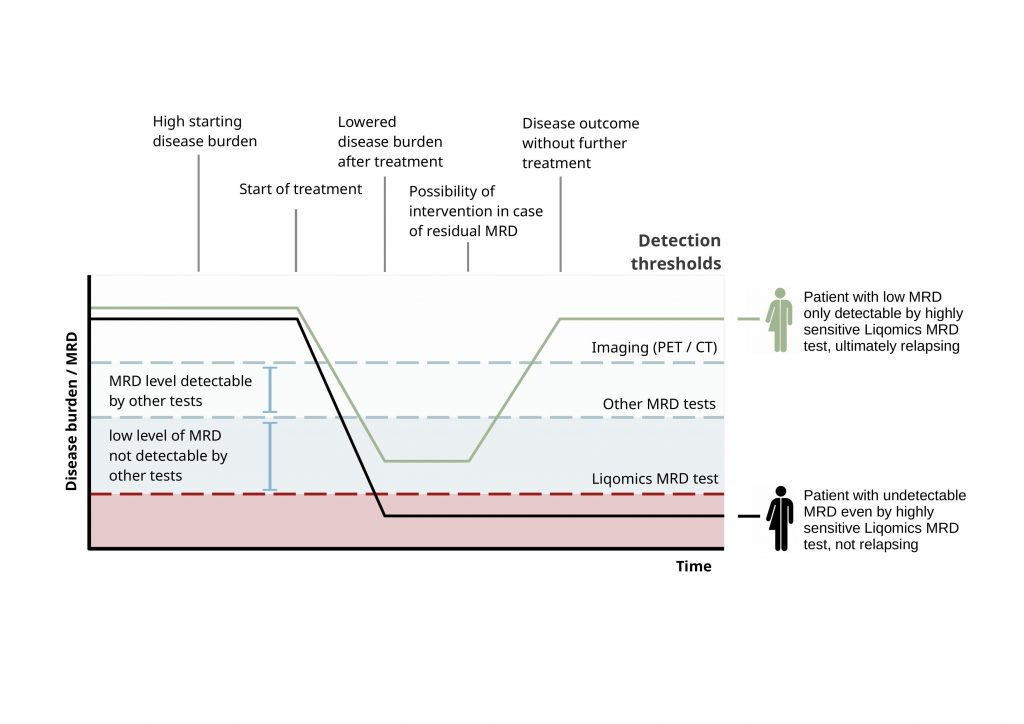

## cell-free DNA

- degraded small DNA fragments (50 - 200 bp)
  - cleaved by nucleases
- released by dead cells
  - mainly through apoptosis, necrosis, active secretion
- contain molecular features characteristic of their tissues of origin
  - fragment size
  - methylation status
  - end motifs

## Nucleosome, Chromatin structure, and nuclease content influence feature characteristics

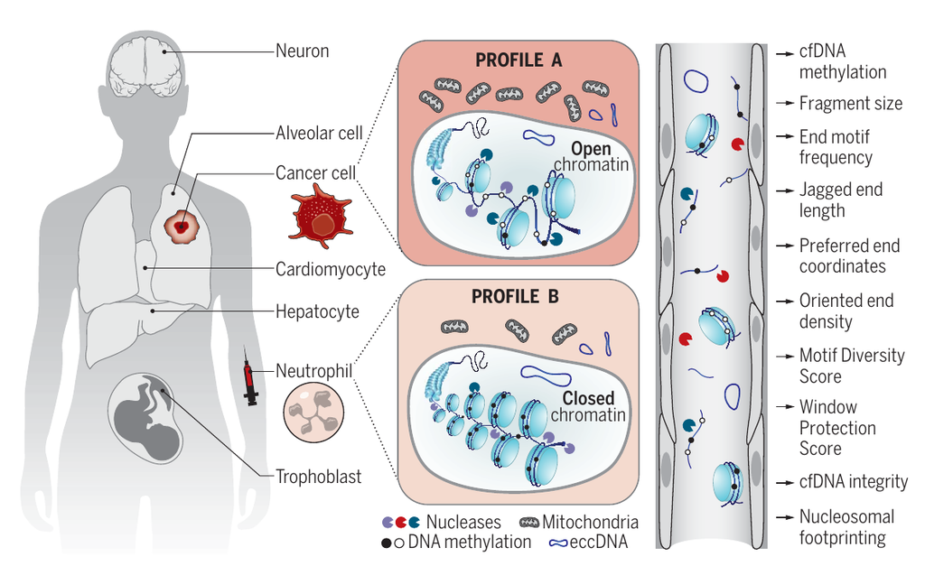

## Projects Overview

1. Hodgkin Lymphoma
   - cell-free DNA sequencing data from Hodgkin Lymphoma Patients
     - data before and after two cycles of chemotherapy
     - information about relapse
   - Goal:
     - Create machine learning model to predict relapse
   - Result:
     - not enough samples to create a good predicting model
2. Solid Tumors (Finale_DB)
   - cell-free DNA sequencing data from 4 publications
     - Jiang_2015, Cristiano_2019, Snyder_2016, Sun_2019
     - over 800 samples in total
     - healthy and cancer samples
   - Goal:
     - Create machine learning model to predict cancer or non-cancer for solid tumors

| Source | Diseases Covered | Total Samples |
| --- | --- | --- |
| Cristiano_2019 | Bile_duct_cancer Breast_cancer Colorectal_cancer Duodenal_cancer Gastric_cancer Healthy Lung_cancer Ovarian_cancer Pancreatic_cancer | 536 |
| Jiang_2015 | Cirrhosis Healthy Hepatitis_B Liver_cancer | 225 |

| Source | Diseases Covered | Total Samples |
| --- | --- | --- |
| Snyder_2016 | Bladder_cancer Breast_cancer Colorectal_cancer Esophageal_cancer Head_and_neck_cancer Healthy Inflammatory_bowel_disease Kidney_cancer Liver_cancer Lung_cancer Ovarian_cancer Pancreatic_cancer Prostat… | 58 |
| Sun_2019 | Colorectal_cancer Liver_transplant | 29 |

## Workflow

1. Downsampling
2. Feature Normalization
3. Feature Selection
4. Machine learning (TPOT)

## Downsampling

```
Number of total samples after downsampling: 848
```

|  | sample | disease | source | chromosome | strand | n_fragments | avg_frag_len | sum_fragments_sample | percent_sample | downsampling_value | downsampling_to | sum_fragments_downsampled | n_remove | n_remove_percent |
| --- | --- | --- | --- | --- | --- | --- | --- | --- | --- | --- | --- | --- | --- | --- |
| 0 | EE85754 | Hepatitis_B | Jiang_2015 | chr1 | reverse | 1330369 | 170 | 16925308 | 7.860235 | 5553160 | 436491 | 5553158 | 893878 | 67.190230 |
| 1 | EE87861 | Breast_cancer | Cristiano_2019 | chr1 | reverse | 1088503 | 169 | 13805538 | 7.884539 | 5553160 | 437841 | 5553161 | 650662 | 59.775856 |
| 2 | EE87860 | Breast_cancer | Cristiano_2019 | chr1 | reverse | 1379473 | 170 | 17319462 | 7.964872 | 5553160 | 442302 | 5553160 | 937171 | 67.936890 |
| 3 | EE87859 | Breast_cancer | Cristiano_2019 | chr1 | reverse | 1345788 | 166 | 16903073 | 7.961795 | 5553160 | 442131 | 5553163 | 903657 | 67.147060 |

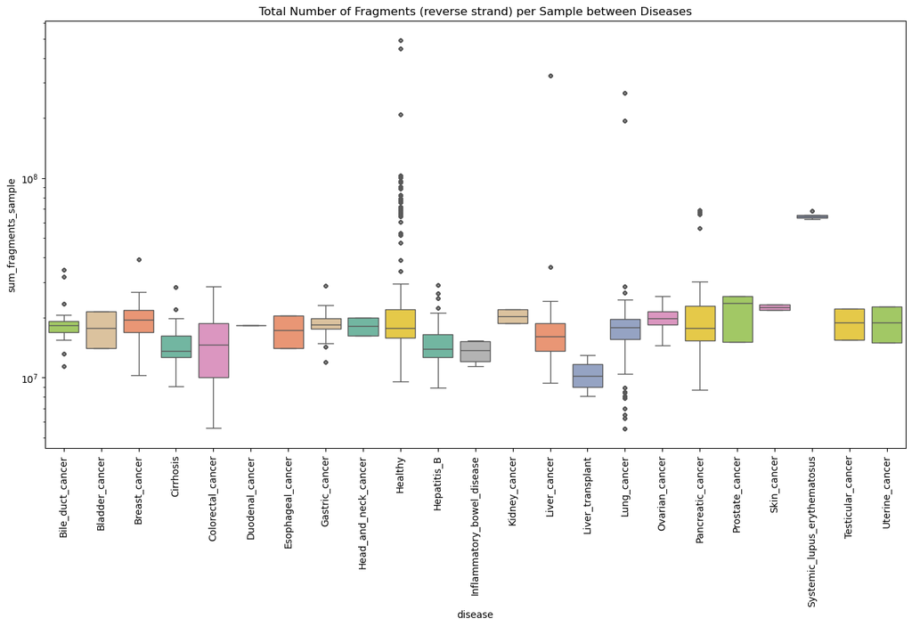

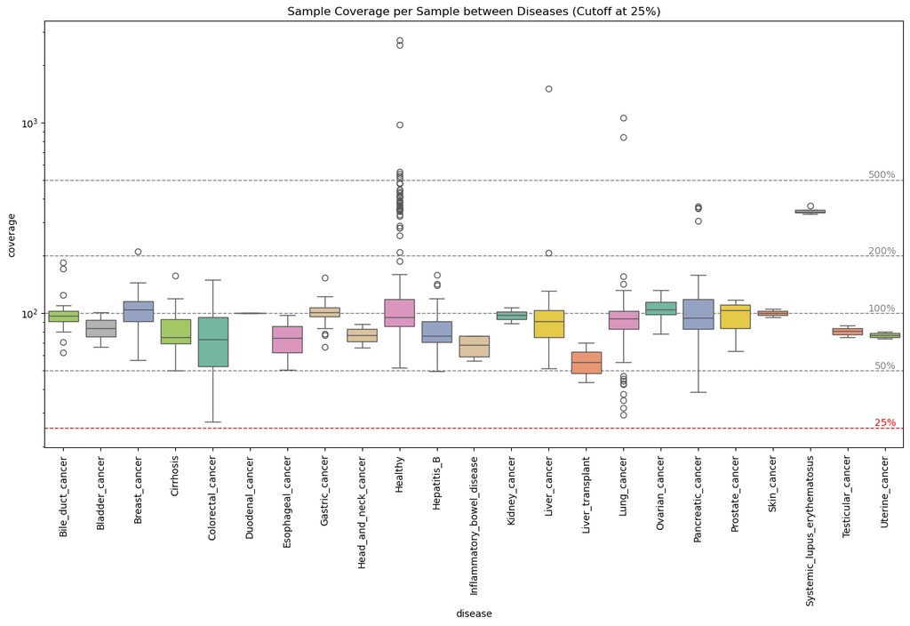

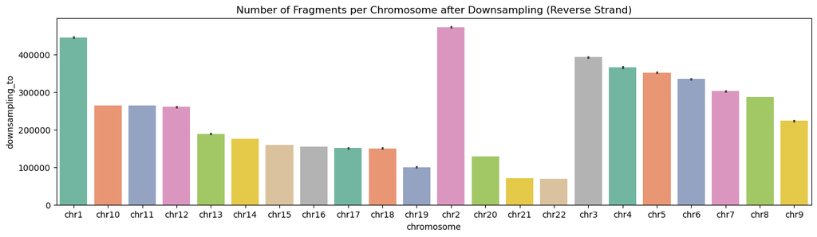

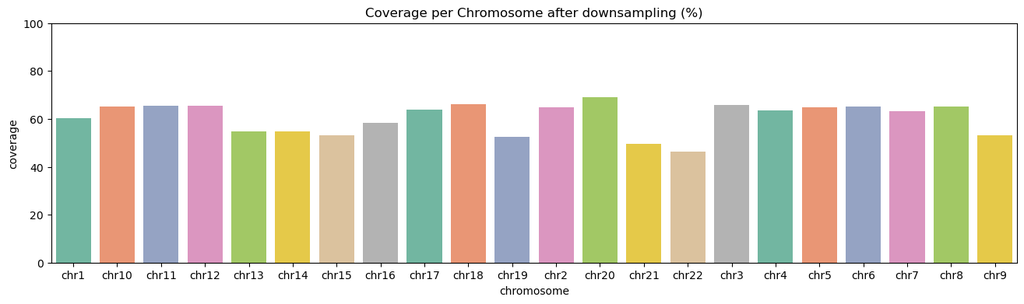

## Feature Normalization

```
### fwd ###
Number of features  after normalization: 78090
Number of features after filtering out columns containing empty or inf values: 76670
Removed features by filtering: 1420

### rev ###
Number of features  after normalization: 78090
Number of features after filtering out columns containing empty or inf values: 76801
Removed features by filtering: 1289
```

| sample | source | disease | target | strand | chr1-P0m-med | chr1-P100m-med | chr1-P105m-med | chr1-P10m-med | chr1-P110m-med | chr1-P115m-med | ... | chr9-P40m-med | chr9-P5m-med | chr9-P60m-med | chr9-P65m-med | chr9-P70m-med | chr9-P75m-med | chr9-P80m-med | chr9-P85m-med | chr9-P90m-med | chr9-P95m-med |
| --- | --- | --- | --- | --- | --- | --- | --- | --- | --- | --- | --- | --- | --- | --- | --- | --- | --- | --- | --- | --- | --- |
| EE85723 | Sun_2019 | Colorectal_cancer | 1 | reverse | 142.0 | 150.0 | 148.5 | 144.5 | 145.0 | 146.0 | ... | 127.0 | 147.0 | 148.0 | 146.5 | 149.5 | 146.0 | 147.0 | 145.0 | 145.5 | 146.0 |
| EE85724 | Sun_2019 | Colorectal_cancer | 1 | reverse | 144.0 | 151.5 | 151.5 | 145.5 | 148.0 | 148.5 | ... | 133.5 | 149.5 | 151.5 | 146.0 | 150.0 | 149.0 | 149.0 | 147.0 | 148.0 | 148.0 |
| EE85725 | Sun_2019 | Liver_transplant | 0 | reverse | 169.5 | 170.5 | 169.0 | 169.0 | 170.5 | 169.5 | ... | 169.0 | 169.5 | 169.0 | 170.5 | 170.0 | 169.0 | 170.0 | 169.0 | 169.5 | 169.5 |
| EE85726 | Sun_2019 | Colorectal_cancer | 1 | reverse | 145.5 | 153.5 | 152.5 | 146.0 | 148.5 | 150.5 | ... | 133.0 | 150.5 | 150.5 | 149.0 | 152.5 | 149.5 | 150.5 | 149.0 | 149.0 | 148.0 |
| EE85727 | Sun_2019 | Colorectal_cancer | 1 | reverse | 142.0 | 151.5 | 150.5 | 144.0 | 147.0 | 147.0 | ... | 128.5 | 149.0 | 150.0 | 148.5 | 150.5 | 148.5 | 148.5 | 147.0 | 148.0 | 147.0 |
| ... | ... | ... | ... | ... | ... | ... | ... | ... | ... | ... | ... | ... | ... | ... | ... | ... | ... | ... | ... | ... | ... |
| EE88321 | Cristiano_2019 | Pancreatic_cancer | 1 | reverse | 168.0 | 167.5 | 167.5 | 167.5 | 167.5 | 167.5 | ... | 168.0 | 167.5 | 168.0 | 167.5 | 167.5 | 168.0 | 167.0 | 167.5 | 167.0 | 167.0 |
| EE88322 | Cristiano_2019 | Pancreatic_cancer | 1 | reverse | 164.5 | 163.5 | 163.0 | 163.5 | 163.5 | 163.5 | ... | 163.0 | 163.5 | 164.5 | 163.5 | 163.0 | 163.0 | 163.5 | 163.0 | 163.0 | 163.5 |
| EE88323 | Cristiano_2019 | Pancreatic_cancer | 1 | reverse | 164.0 | 164.5 | 164.5 | 164.0 | 164.5 | 164.0 | ... | 164.5 | 164.0 | 164.0 | 164.0 | 164.0 | 164.5 | 164.5 | 164.0 | 163.5 | 164.5 |
| EE88324 | Cristiano_2019 | Pancreatic_cancer | 1 | reverse | 166.0 | 166.5 | 166.0 | 166.0 | 166.0 | 167.0 | ... | 167.0 | 166.0 | 166.5 | 166.0 | 166.5 | 166.0 | 167.0 | 166.0 | 166.5 | 166.5 |
| EE88325 | Cristiano_2019 | Bile_duct_cancer | 1 | reverse | 163.5 | 163.0 | 163.0 | 163.5 | 162.5 | 162.0 | ... | 163.0 | 162.0 | 163.5 | 162.5 | 162.5 | 163.0 | 163.0 | 163.5 | 163.5 | 162.5 |

848 rows × 573 columns

### Feature Visualization

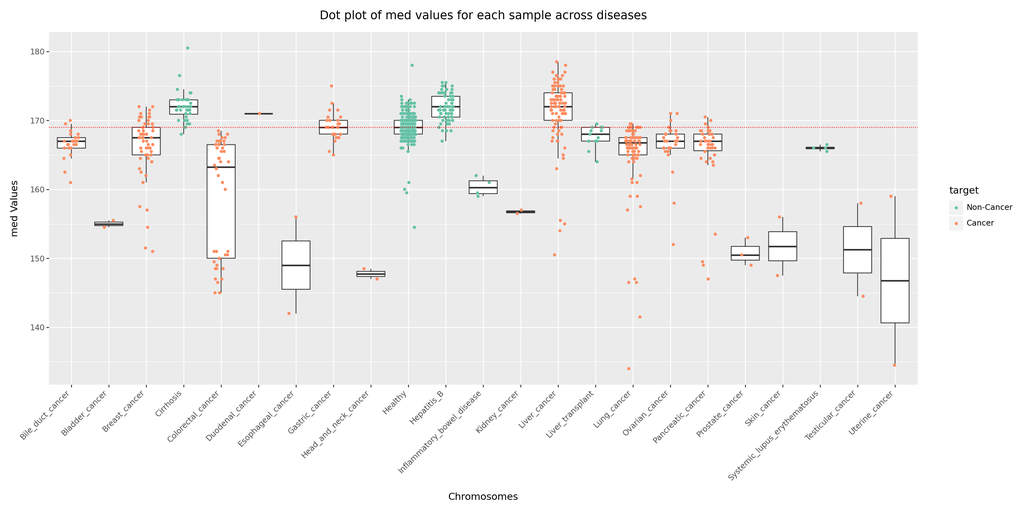

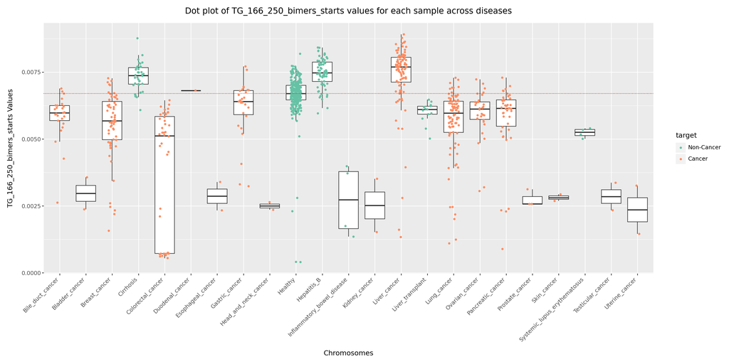

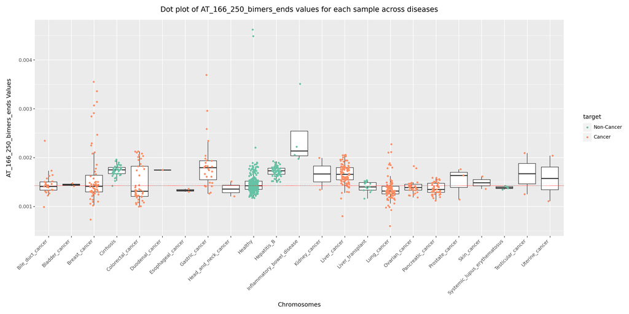

## Feature Selection

```
Feature Selection Samples: 42
Remaining Samples for Model Training: 806
```

| sample | chr1-P140m-AC_166_250_bimers_ends | chr1-P145m-CA_166_250_bimers_ends | chr1-P155m-TA_166_250_bimers_ends | chr1-P215m-GG_80_165_bimers_starts | chr1-P70m-GT_bimers_starts | chr1-P90m-bimers_end_80_165_mds | chr10-P20m-CG_166_250_bimers_ends | chr11-P130m-AT_166_250_bimers_starts | chr11-P25m-CGN_NCG_ratios | chr11-P35m-bimers_start_80_165_mds | ... | chr7-P65m-AC_166_250_bimers_ends | chr7-P65m-GT_166_250_bimers_starts | chr8-P115m-CG_166_250_bimers_starts | chr8-P125m-bimers_end_80_165_mds | chr8-P40m-AG_bimers_ends | chr9-P100m-AA_166_250_bimers_ends | chr9-P125m-CT_bimers_starts | chr9-P30m-CGN_NCG_ratios | chr9-P60m-CG_bimers_ends | chr9-P65m-AG_166_250_bimers_starts |
| --- | --- | --- | --- | --- | --- | --- | --- | --- | --- | --- | --- | --- | --- | --- | --- | --- | --- | --- | --- | --- | --- |
| EE87914 | 0.004662 | 0.002667 | 0.002361 | 0.002032 | 0.061149 | 0.732766 | 0.000490 | 0.002611 | 1.368421 | 0.727566 | ... | 0.003424 | 0.003203 | 0.000374 | 0.734192 | 0.077093 | 0.002699 | 0.076003 | 1.838710 | 0.008621 | 0.001907 |
| EE85729 | 0.000000 | 0.005612 | 0.004261 | 0.001777 | 0.025653 | 0.720809 | 0.001251 | 0.001136 | 1.075000 | 0.721542 | ... | 0.001052 | 0.001052 | 0.000383 | 0.714684 | 0.070532 | 0.001659 | 0.070795 | 1.059701 | 0.018830 | 0.003297 |

2 rows × 78 columns

## TPOT

### Classifier Performance on Training Data

Table: Best Classifiers after training

|  | Classifier | Hyperparameter_Count | Accuracy | Sensitivity | Specificity | Weighted_Score |
| --- | --- | --- | --- | --- | --- | --- |
| 0 | BernoulliNB | 475 | 0.581818 | 0.240984 | 0.928333 | 0.652825 |
| 8 | ExtraTreesClassifier | 55 | 0.788430 | 0.660656 | 0.918333 | 0.815049 |
| 138 | RandomForestClassifier | 228 | 0.814876 | 0.762295 | 0.868333 | 0.825830 |
| 266 | XGBClassifier | 459 | 0.806612 | 0.798361 | 0.815000 | 0.808331 |

### Selected Classifiers for Final Classifier Train Set

| Classifier | Count |
| --- | --- |
| RandomForestClassifier | 151 |
| XGBClassifier | 8 |

### Feature Importance for Training Data

|  | Feature | RandomForestClassifier_228 | Feature | XGBClassifier_459 |
| --- | --- | --- | --- | --- |
| 0 | chr15-P60m-coverage | 0.039722 | chr15-P60m-coverage | 0.046827 |
| 1 | chr20-P5m-coverage | 0.035050 | chr5-P65m-AG_bimers_ends | 0.042846 |
| 2 | chr9-P125m-CT_bimers_starts | 0.029529 | chr4-P180m-AG_bimers_ends | 0.042642 |
| 3 | chr5-P65m-AG_bimers_ends | 0.028884 | chr9-P125m-CT_bimers_starts | 0.029304 |
| 4 | chr8-P40m-AG_bimers_ends | 0.027697 | chr5-P100m-AG_bimers_ends | 0.026779 |
| 5 | chr5-P140m-coverage | 0.026865 | chr20-P5m-coverage | 0.025904 |
| 6 | chr5-P100m-AG_bimers_ends | 0.026772 | chr3-P90m-bimers_start_mds | 0.022920 |
| 7 | chr13-P95m-AG_166_250_bimers_starts | 0.026503 | chr8-P40m-AG_bimers_ends | 0.021738 |
| 8 | chr12-P70m-AG_166_250_bimers_starts | 0.025008 | chr13-P95m-AG_166_250_bimers_starts | 0.021229 |
| 9 | chr4-P180m-AG_bimers_ends | 0.024981 | chr2-P0m-TC_166_250_bimers_starts | 0.020504 |

| Feature | RandomForestClassifier_228 | XGBClassifier_459 |
| --- | --- | --- |
| chr15-P60m-coverage | 1 | 1 |
| chr20-P5m-coverage | 2 | 6 |
| chr9-P125m-CT_bimers_starts | 3 | 4 |
| chr5-P65m-AG_bimers_ends | 4 | 2 |
| chr8-P40m-AG_bimers_ends | 5 | 8 |
| chr5-P100m-AG_bimers_ends | 7 | 5 |
| chr13-P95m-AG_166_250_bimers_starts | 8 | 9 |
| chr4-P180m-AG_bimers_ends | 10 | 3 |

### Classifier Performance on Blind Test Set

|  | Classifier | Accuracy | Sensitivity | Specificity | Confusion_Matrix | Weighted_Score |
| --- | --- | --- | --- | --- | --- | --- |
| 101 | RandomForestClassifier_228 | 1.0 | 1.0 | 1.0 | [[81 0]\n [ 0 81]] | 1.0 |
| 161 | XGBClassifier_459 | 1.0 | 1.0 | 1.0 | [[81 0]\n [ 0 81]] | 1.0 |

|  | Classifier | Accuracy | Sensitivity | Specificity | Confusion_Matrix | Weighted_Score |
| --- | --- | --- | --- | --- | --- | --- |
| 95 | RandomForestClassifier_198 | 0.882716 | 0.814815 | 0.950617 | [[77 4]\n [15 66]] | 0.896296 |
| 154 | XGBClassifier_359 | 0.888889 | 0.827160 | 0.950617 | [[77 4]\n [14 67]] | 0.901235 |

|  | Feature | Importance_RandomForestClassifier_228 | Feature | Importance_XGBClassifier_459 |
| --- | --- | --- | --- | --- |
| 0 | chr15-P60m-coverage | 0.038427 | chr15-P60m-coverage | 0.055340 |
| 1 | chr20-P5m-coverage | 0.036640 | chr8-P40m-AG_bimers_ends | 0.054111 |
| 2 | chr9-P125m-CT_bimers_starts | 0.035704 | chr5-P65m-AG_bimers_ends | 0.052793 |
| 3 | chr8-P40m-AG_bimers_ends | 0.032551 | chr9-P125m-CT_bimers_starts | 0.032789 |
| 4 | chr4-P180m-AG_bimers_ends | 0.028668 | chr4-P180m-AG_bimers_ends | 0.026407 |
| 5 | chr5-P140m-coverage | 0.026348 | chr4-P50m-GT_80_165_bimers_starts | 0.024639 |
| 6 | chr5-P100m-AG_bimers_ends | 0.026063 | chr20-P5m-coverage | 0.021794 |
| 7 | chr3-P90m-bimers_start_mds | 0.025871 | chr12-P70m-AG_166_250_bimers_starts | 0.021741 |
| 8 | chr20-P35m-GA_166_250_bimers_ends | 0.025727 | chr3-P90m-bimers_start_mds | 0.021711 |
| 9 | chr5-P65m-AG_bimers_ends | 0.024950 | chr14-P60m-TC_80_165_bimers_ends | 0.021705 |

| Feature | Importance_RandomForestClassifier_228 | Importance_XGBClassifier_459 |
| --- | --- | --- |
| chr15-P60m-coverage | 1 | 1 |
| chr20-P5m-coverage | 2 | 7 |
| chr9-P125m-CT_bimers_starts | 3 | 4 |
| chr8-P40m-AG_bimers_ends | 4 | 2 |
| chr4-P180m-AG_bimers_ends | 5 | 5 |
| chr3-P90m-bimers_start_mds | 8 | 9 |
| chr5-P65m-AG_bimers_ends | 10 | 3 |

### Compare Feature Importance of Training and Blind Test Set

| Feature | RandomForestClassifier_228 | XGBClassifier_459 | Blind_Testing_RandomForestClassifier_228 | Blind_Testing_XGBClassifier_459 |
| --- | --- | --- | --- | --- |
| chr13-P95m-AG_166_250_bimers_starts | 8 | 9 | - | - |
| chr15-P60m-coverage | 1 | 1 | 1 | 1 |
| chr20-P5m-coverage | 2 | 6 | 2 | 7 |
| chr3-P90m-bimers_start_mds | - | - | 8 | 9 |
| chr4-P180m-AG_bimers_ends | 10 | 3 | 5 | 5 |
| chr5-P100m-AG_bimers_ends | 7 | 5 | - | - |
| chr5-P65m-AG_bimers_ends | 4 | 2 | 10 | 3 |
| chr8-P40m-AG_bimers_ends | 5 | 8 | 4 | 2 |
| chr9-P125m-CT_bimers_starts | 3 | 4 | 3 | 4 |

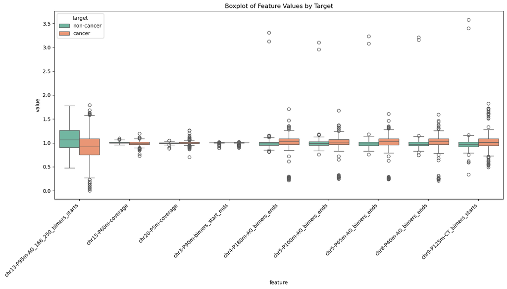

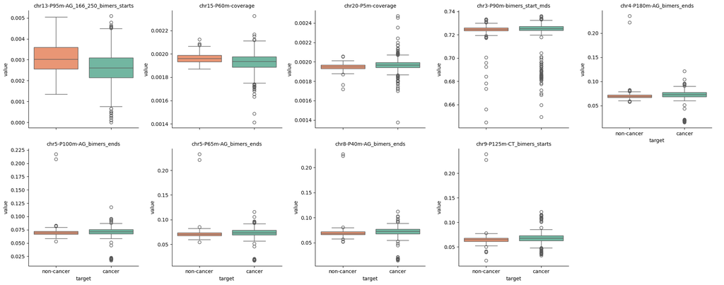